# 9_mr_loneliness_depression_triglycerides

Ellen Martin

2026-11-06

## Mendelian randomization for Loneliness -> Triglycerides, Loneliness -> Depression and Triglycerides -> Depression

Primary analyses: PanUKB loneliness → triglycerides → depression. AoU loneliness is a sensitivity exposure. The pairwise analyses below estimate each link; they do not, by themselves, estimate a formal indirect/mediation effect.

Notes: - everything should be Hg38 build for coordinates, so make sure plink build is correct -

### Read and standardize summary statistics

The AoU file uses `CHROM`, `GENPOS`, `ID`, `ALLELE0`, `ALLELE1`, `N`, `TEST`, `BETA`, `SE`, and `LOG10P`. The additive (`ADD`) rows are retained; `ALLELE1` is treated as the effect allele for `BETA`, and `ALLELE0` as the other allele. Confirm that allele convention against the AoU export documentation before interpreting direction.

Other files are expected to have the standardized columns `SNP`, `A1`, `A2`, `BETA`, `SE`, `P`, and `N` (with optional `CHR`, `BP`, `EAF`).

### TwoSampleMR

- Note, this uses a reduced thrshold of 5e-6
- 5e-8 will be run as sensitivity analyses, but not many things survive

#### Relaxed Threshold Two-Sample MR

- 5e-6

#### Check Mapping Issues

- with AoU Chr:BP specifically

#### Sensitivity with Stringent Threshold

- 5e-8

#### Bidirectional MR

- we tested loneliness -> triglycerides, loneliness -> depression/T2D and triglycerides -> depression/T2D
- now we can test
1. depression -> triglycerides, depression -> loneliness, triglycerides -> loneliness
2. T2D -> triglycerides, T2D -> loneliness
- evidence of Triglycerides -> PanUKB loneliness, consistent across IVW and WM (beta IVW = 0.078, p < 0.001, nSNPS = 485).
- evidence of Depression -> PanUKB Loneliness, consistent across all MR methods (beta IVW = 0.477, p < 0.001, nSNPS = 131)
- evidence of Depression -> Triglycerides -> consistent across IVW and WM (beta IVW = 0.156, p = 0.004, nSNPS = 60)
- weak evidence of T2D -> AoU Loneliness only WM (beta WM = 0.72, p = 0.04, nSNPS = 6)
- weak evidence of T2D -> PanUKB Loneliness only IVW (beta IVW = 0.035, p = 0.002, nSNPS = 395)
- evidence of T2D -> Triglycerides, consistent across IVW and WM (beta IVW = 0.114, p < 0.001, nSNPS = 186)

#### Reversed, Stringent Results (5e-8)

- bidirectional loneliness <-> depression effects
- bidirectional T2D <-> triglycerides relationship
- some evidence of triglycerides -> loneliness
- some evidence of depression -> Triglycerides

triglycerides -> loneliness triglycerides -> T2D

### MR Sensitivity Analyses

- all comparisons show significant heterogentiy (Cochran’s Q)
- significant egger intercepts for:
  - loneliness (PanUKB) -> depression
  - triglycerides -> depression
  - triglycerides -> type 2 diabetes
  - triglycerides -> panUKB loneliness
  - type 2 diabetes -> panUKB loneliness
  - type 2 diabetes -> triglycerides
- at stringent threshold:
  - dep -> PanUKB
  - dep -> tg
  - T2D -> tg
  - PanUKB lone -> TG
  - PanUKB -> T2D
  - TG -> T2D

#### Forest Plot with All Four Methods (Relaxed)

```
## `height` was translated to `width`.
```

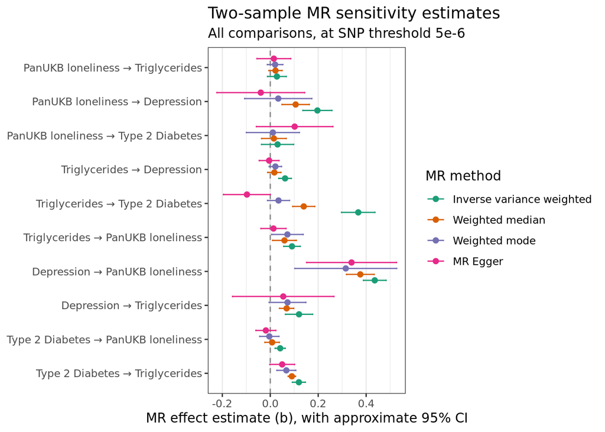

- including sensitivity analyses, strongest evidence for: - Depression -> PanUKB Loneliness - Type 2 Diabetes -> Triglycerides - Triglycerides -> PanUKB Loneliness (to a degree, except MR Egger) - Depression -> Triglycerides also except for MR Egger which has a wide confidence interval

#### Forest Plot with All Four Methods (Stringent)

```
## `height` was translated to `width`.
```

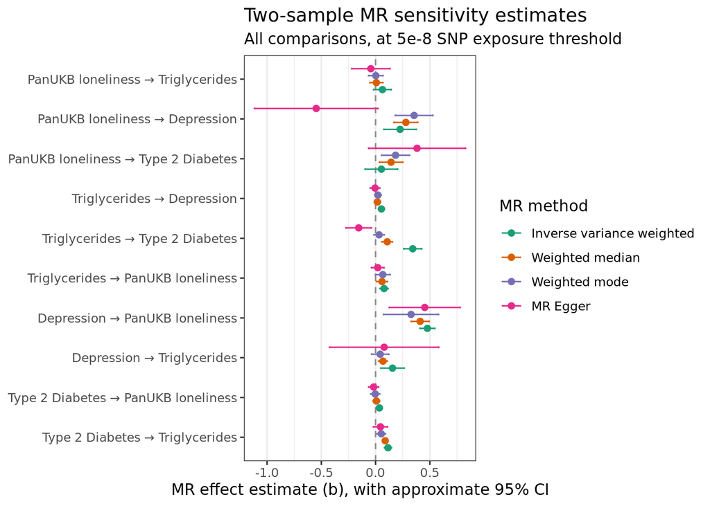

#### Separate plot for AoU sensitivity analyses

- since confidence intervals are super wide

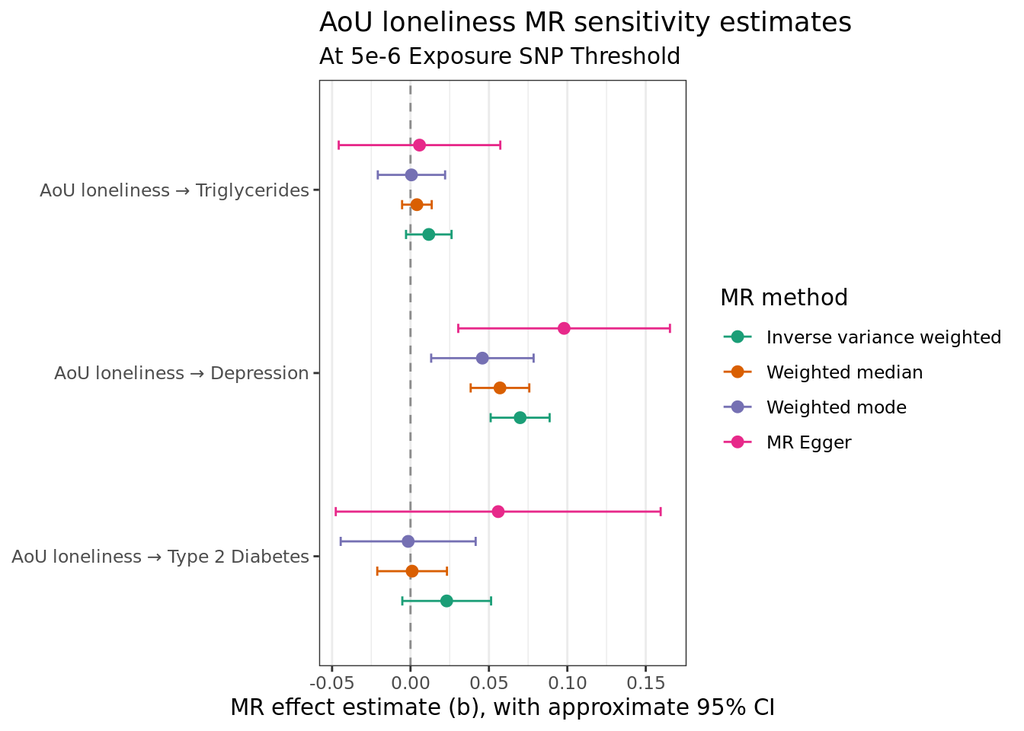

- for AoU, most consistent evidence of an effect from loneliness to depression

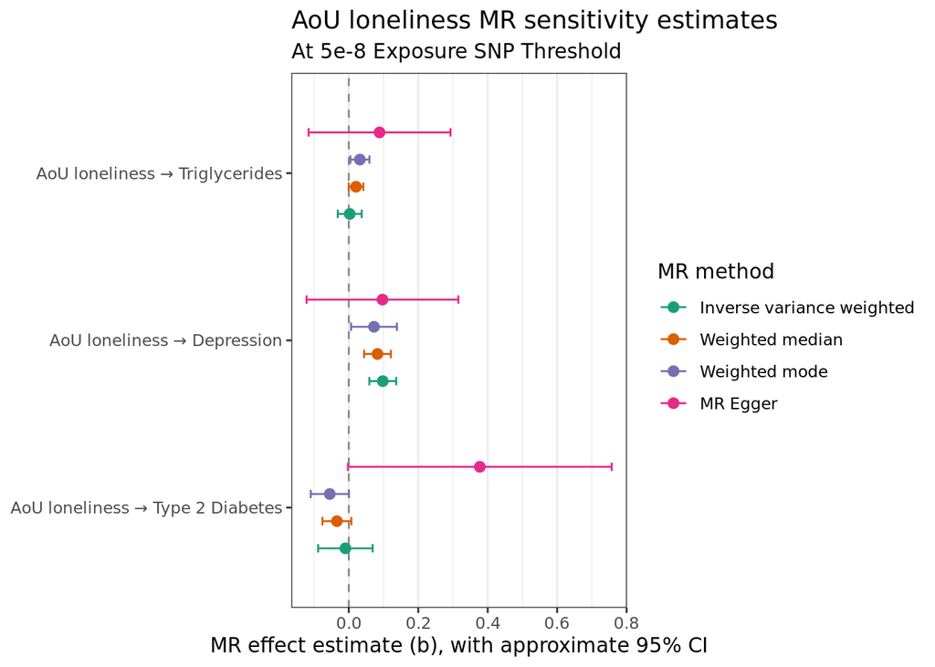

- all instrumnents of adequate strength (no F < 10)

#### Looking at SNP effects for strongest pairs

1. Loneliness -> Depression
2. Depression -> Loneliness
3. Triglycerides -> T2D
4. T2D -> Triglycerides
5. Triglycerides -> Loneliness
- possible weak causal chain from T2D -> Triglycerides -> loneliness?

#### Single SNP Results

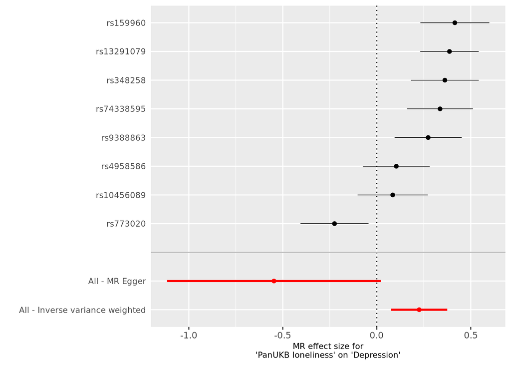

```r
# Loneliness to Depression (PanUKB)
dep_single_snp <- subset(
  single_snp_results_stringent,
  comparison == "panukb_to_dep_stringent"
)

mr_forest_plot(dep_single_snp)
```

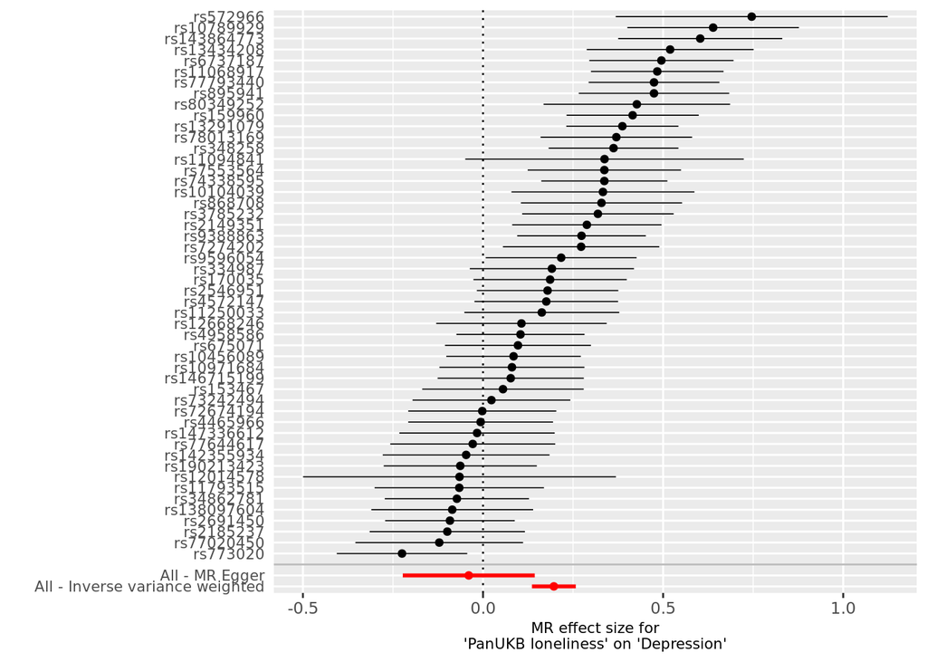

```r
# Loneliness to Depression (PanUKB)
dep_single_snp_rel <- subset(
  single_snp_results,
  comparison == "panukb_to_dep"
)

mr_forest_plot(dep_single_snp_rel)
```

- with a relaxed threshold, it looks more apparent that there is some kind of effect of loneliness on depression

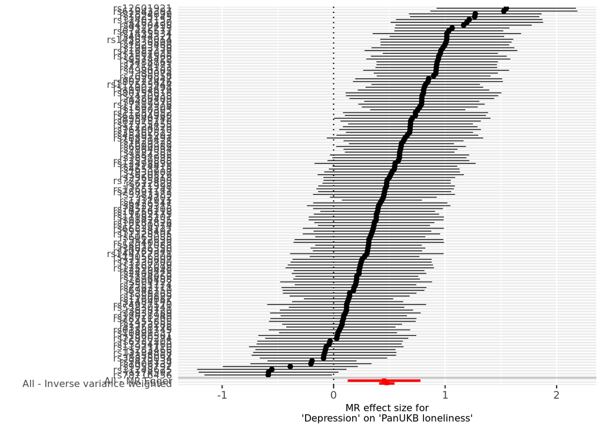

```r
dep_single_snp <- subset(
  single_snp_results_stringent,
  comparison == "dep_to_panukb_stringent"
)

mr_forest_plot(dep_single_snp)
```

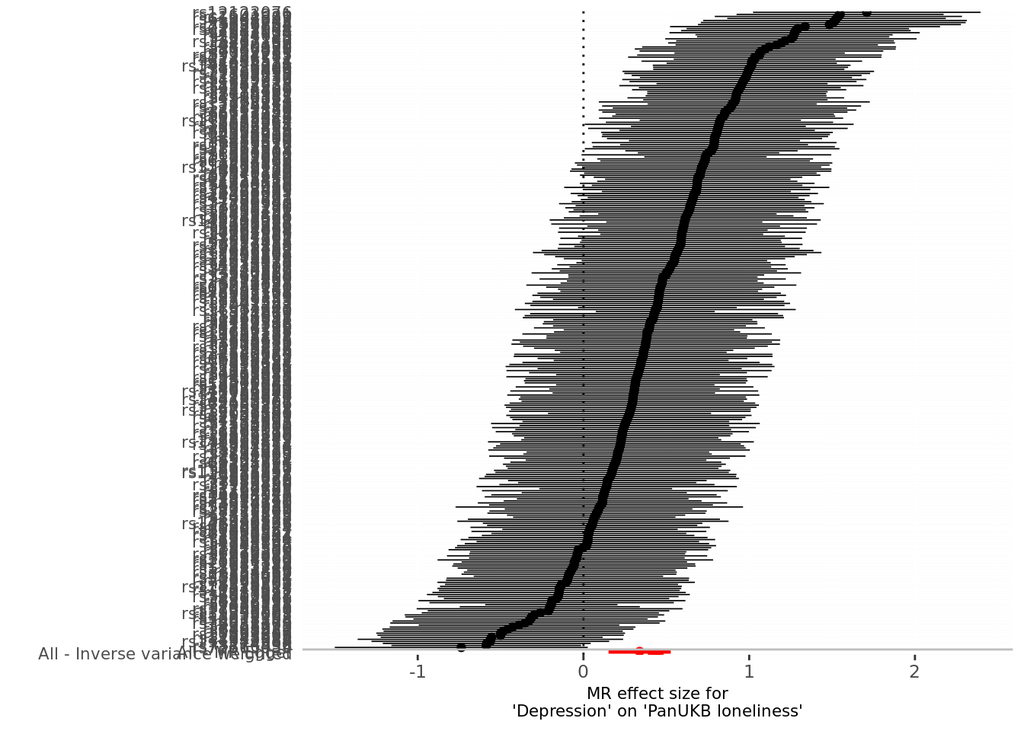

```r
dep_single_snp_rel <- subset(
  single_snp_results,
  comparison == "dep_to_panukb"
)

mr_forest_plot(dep_single_snp_rel)
```

- much more of an effect of Depression on PanUKB loneliness (and way more SNPs significant at thresholds)

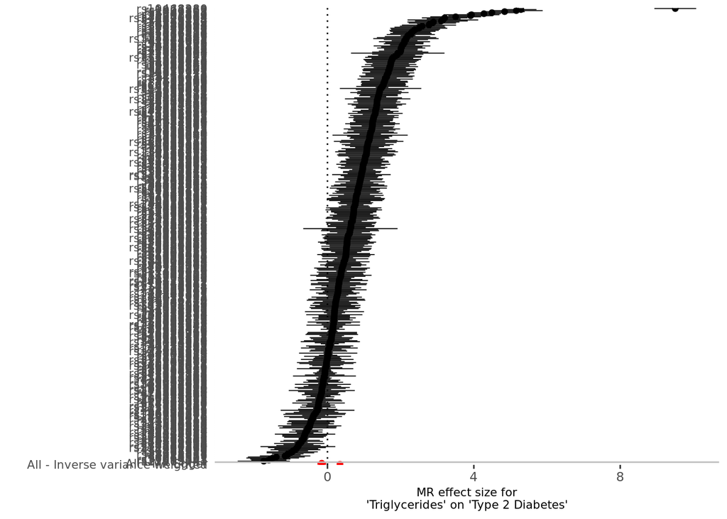

```r
tg_single_snp <- subset(
  single_snp_results_stringent,
  comparison == "tg_to_t2d_stringent"
)

mr_forest_plot(tg_single_snp)
```

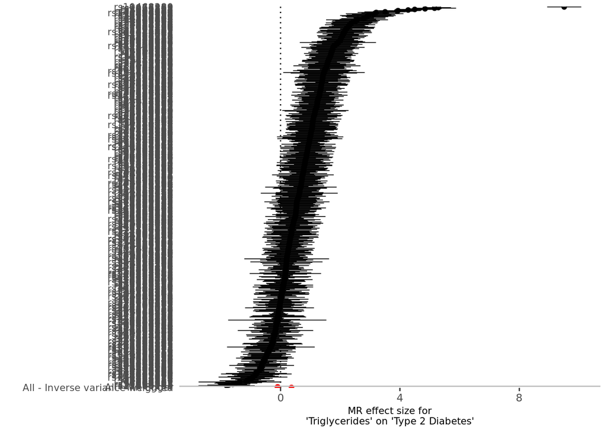

```r
tg_single_snp_rel <- subset(
  single_snp_results,
  comparison == "tg_to_t2d"
)

mr_forest_plot(tg_single_snp_rel)
```

- some evidence of tg to t2d, but so many SNPS

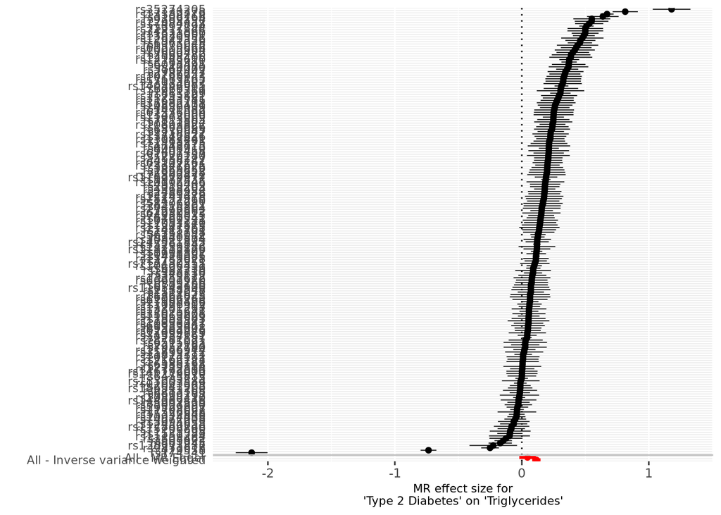

```r
t2d_single_snp <- subset(
  single_snp_results_stringent,
  comparison == "t2d_to_tg_stringent"
)

mr_forest_plot(t2d_single_snp)
```

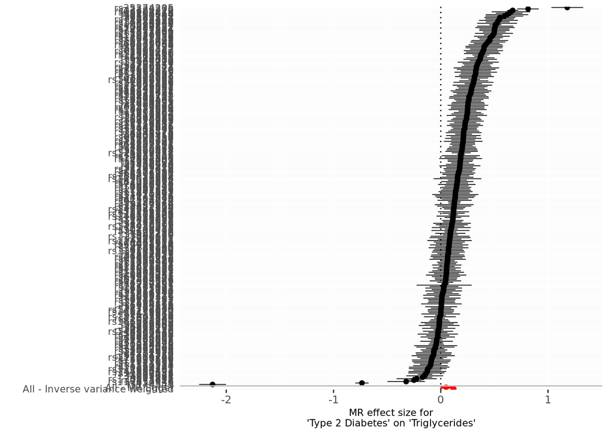

```r
t2d_single_snp_rel <- subset(
  single_snp_results,
  comparison == "t2d_to_tg"
)

mr_forest_plot(t2d_single_snp_rel)
```

- more convincing evidence of T2D -> Triglycerides

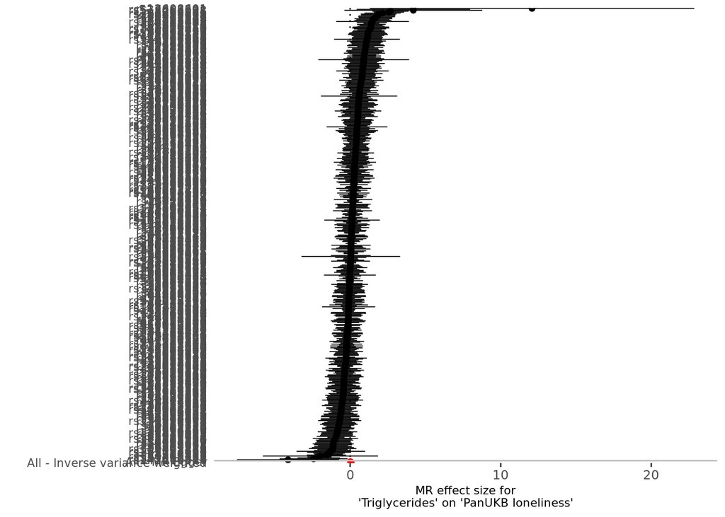

```r
lone_single_snp <- subset(
  single_snp_results_stringent,
  comparison == "tg_to_panukb_stringent"
)

mr_forest_plot(lone_single_snp)
```

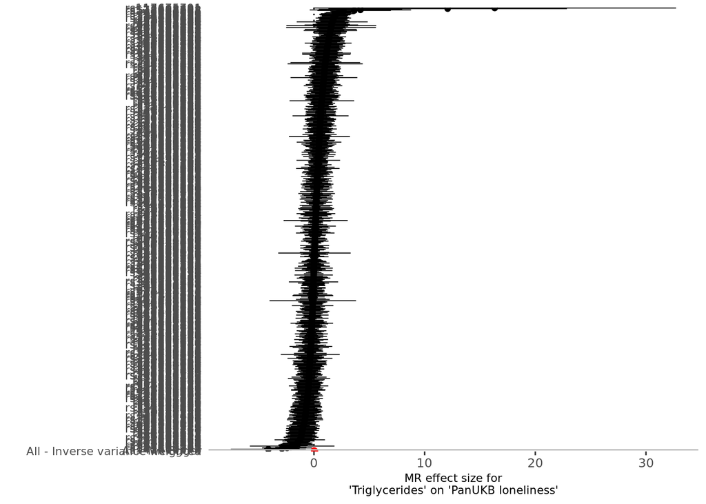

```r
lone_single_snp_rel <- subset(
  single_snp_results,
  comparison == "tg_to_panukb"
)

mr_forest_plot(lone_single_snp_rel)
```

- basically zero

#### Leave-one-out Plots

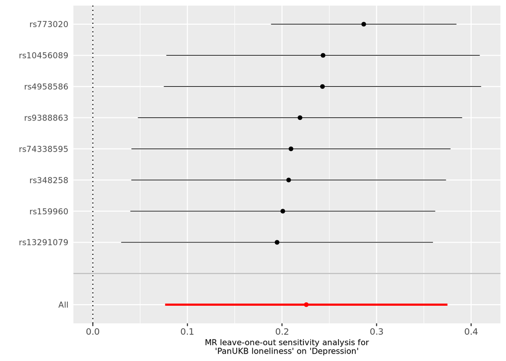

```r
# Loneliness to Depression (PanUKB)
dep_loo <- subset(
  leave_one_out_results_stringent,
  comparison == "panukb_to_dep_stringent"
)

mr_leaveoneout_plot(dep_loo)
```

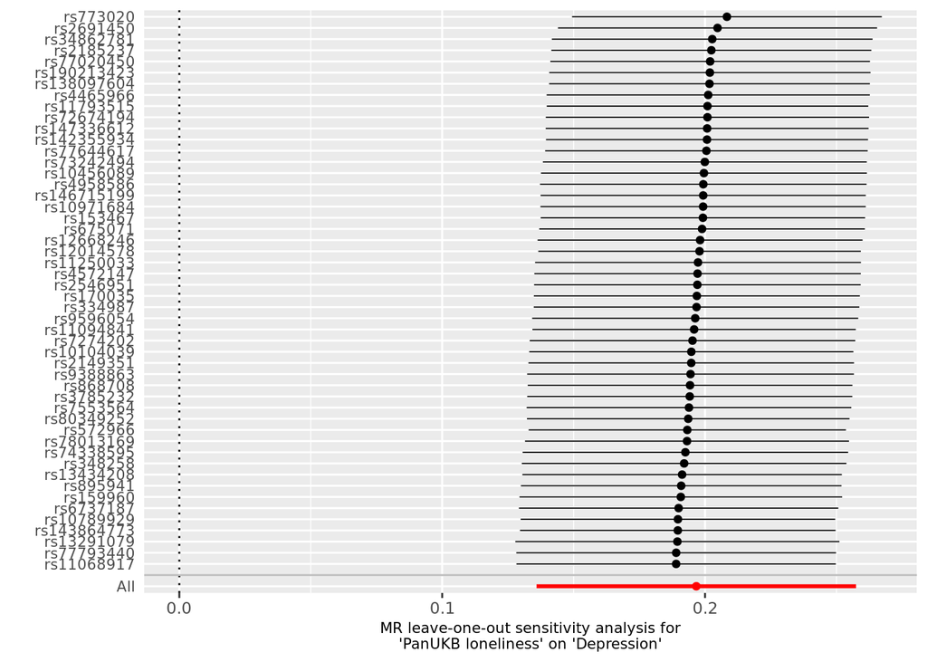

```r
# Loneliness to Depression (PanUKB)
dep_loo_rel <- subset(
  leave_one_out_results,
  comparison == "panukb_to_dep"
)

mr_leaveoneout_plot(dep_loo_rel)
```

- using loo for the stringent threshold, there is still evidence of an effect of Loneliness -> Depression - using loo for the relaxed threshold the effect also remains

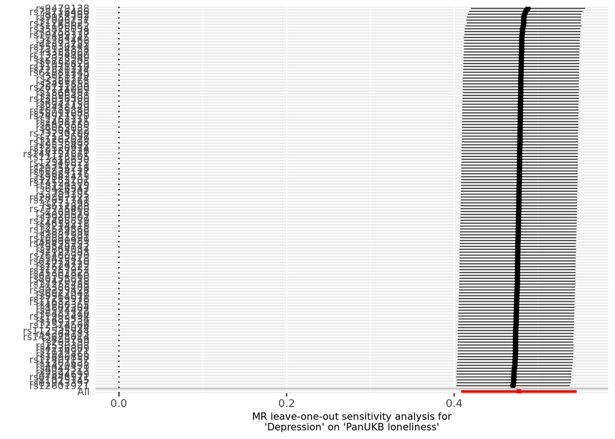

```r
dep_loo <- subset(
  leave_one_out_results_stringent,
  comparison == "dep_to_panukb_stringent"
)

mr_leaveoneout_plot(dep_loo)
```

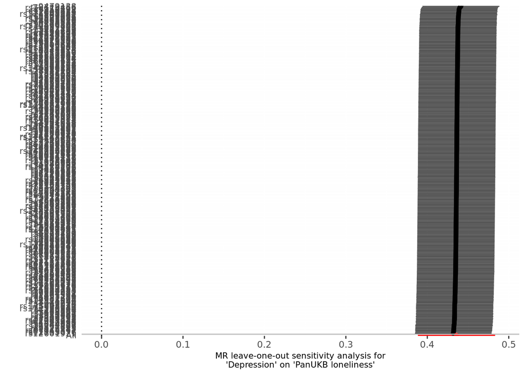

```r
dep_loo_rel <- subset(
  leave_one_out_results,
  comparison == "dep_to_panukb"
)

mr_leaveoneout_plot(dep_loo_rel)
```

- for both, the effect of Dep -> Lone remains

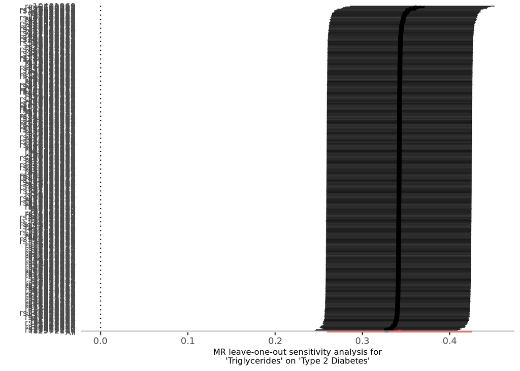

```r
tg_loo <- subset(
  leave_one_out_results_stringent,
  comparison == "tg_to_t2d_stringent"
)

mr_leaveoneout_plot(tg_loo)
```

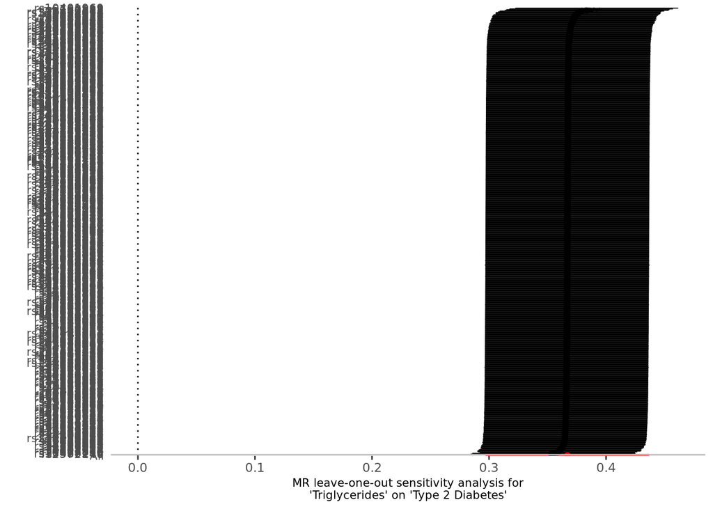

```r
tg_loo_rel <- subset(
  leave_one_out_results,
  comparison == "tg_to_t2d"
)

mr_leaveoneout_plot(tg_loo_rel)
```

- loo results still show triglycerides -> T2D significant

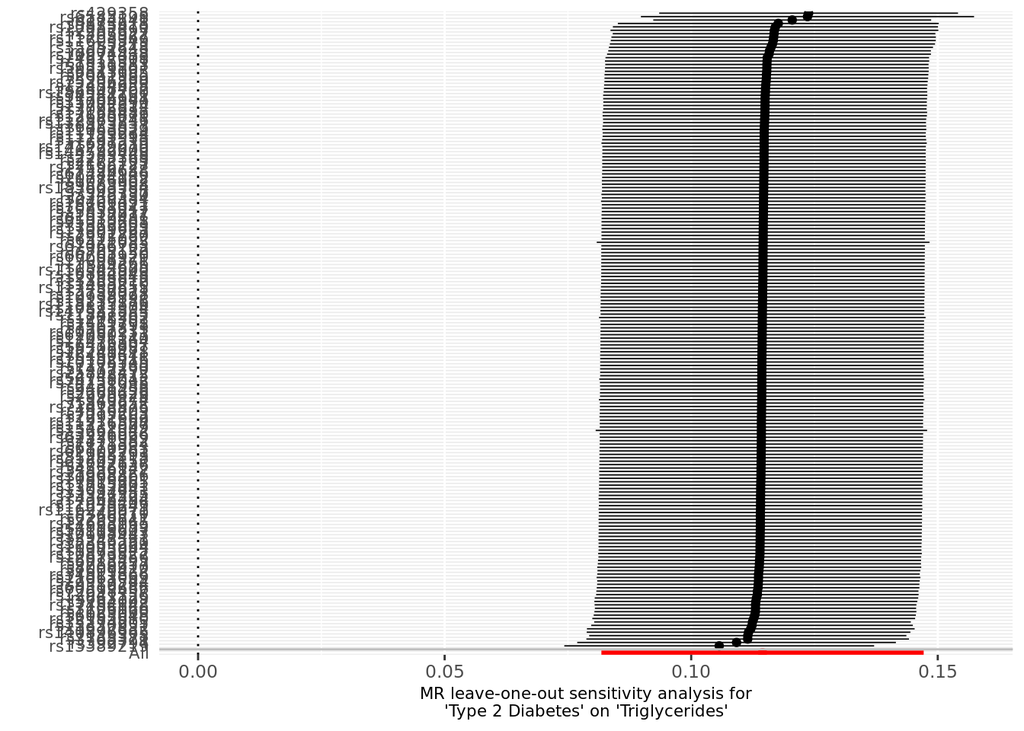

```r
tg_loo <- subset(
  leave_one_out_results_stringent,
  comparison == "t2d_to_tg_stringent"
)

mr_leaveoneout_plot(tg_loo)
```

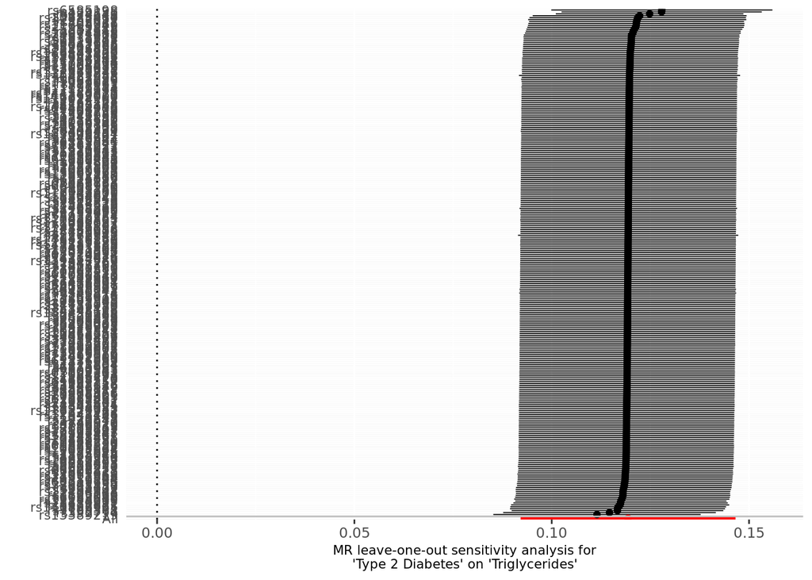

```r
tg_loo_rel <- subset(
  leave_one_out_results,
  comparison == "t2d_to_tg"
)

mr_leaveoneout_plot(tg_loo_rel)
```

- T2D -> TG still significant

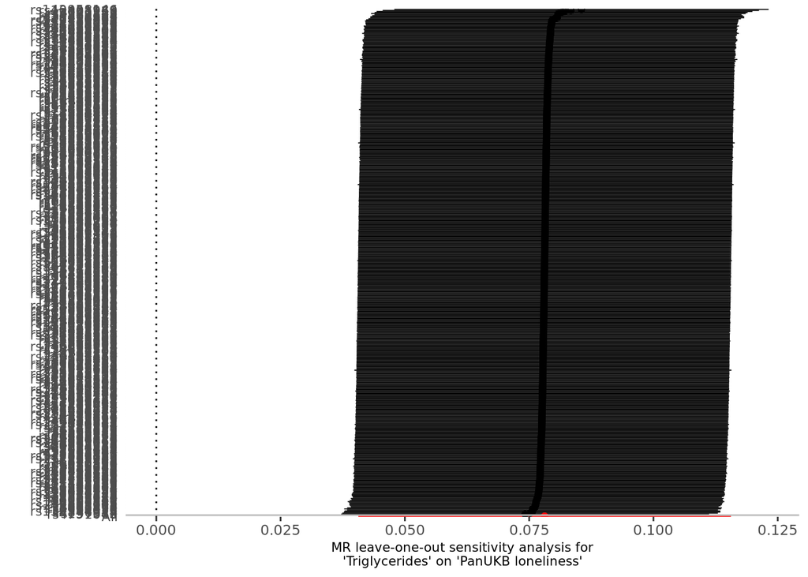

```r
lone_loo <- subset(
  leave_one_out_results_stringent,
  comparison == "tg_to_panukb_stringent"
)

mr_leaveoneout_plot(lone_loo)
```

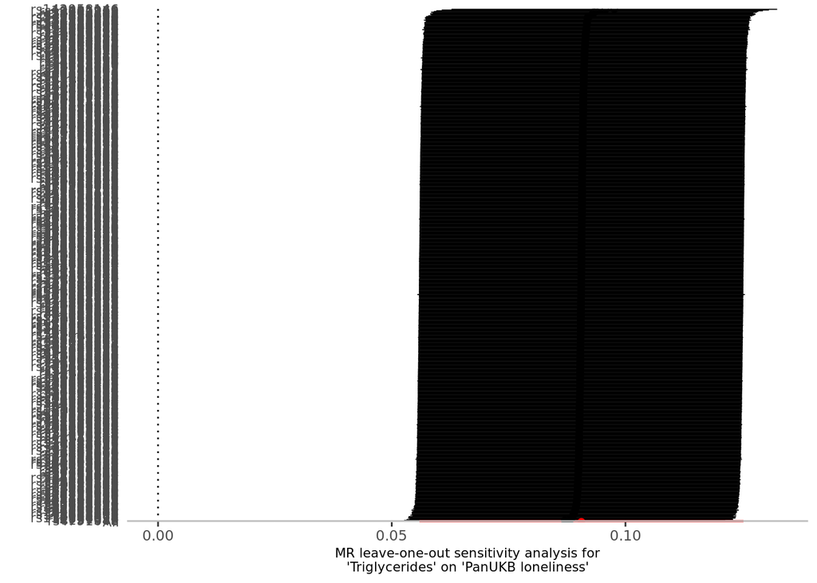

```r
lone_loo_rel <- subset(
  leave_one_out_results,
  comparison == "tg_to_panukb"
)

mr_leaveoneout_plot(lone_loo_rel)
```

- significant effects using loo, suggesting effects aren’t being driven by single powerful SNPs

#### MR-PRESSO

```r
library(MRPRESSO)
```

#### Checking MR Results Adjusting for horizontal pleiotropy

#### Plotting MR PRESSO Results (Lone -> Depression)

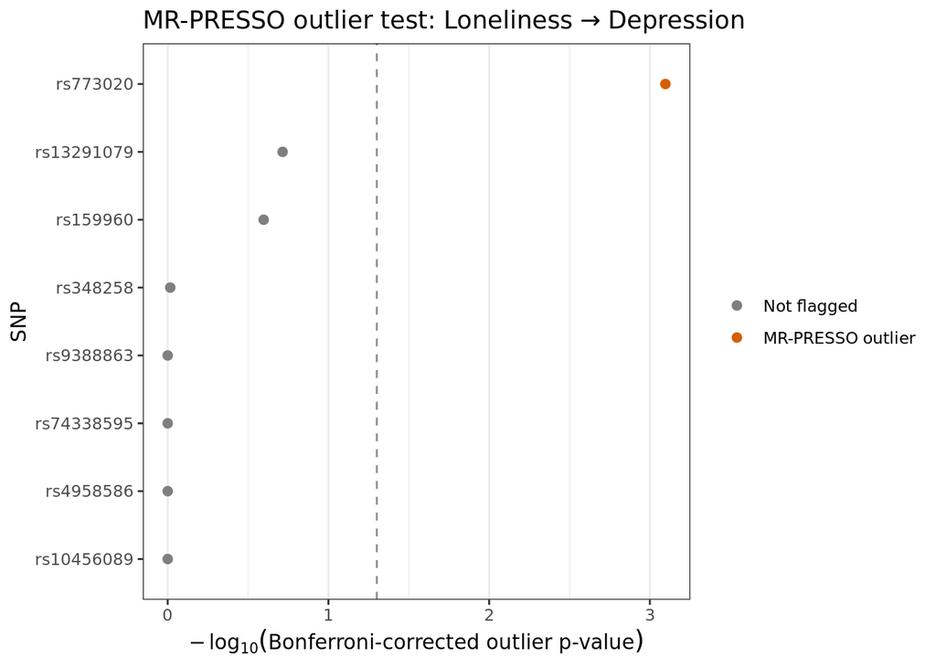

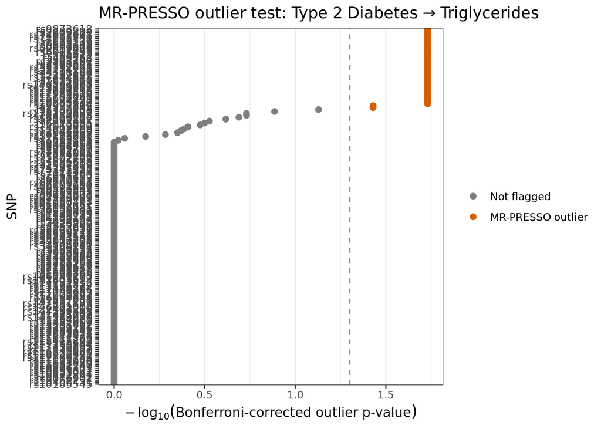

- several MR-PRESSO outliers, but distortion test also n.s.